# IMDb: Who Makes Good/Bad Movies?

Instruction  
探討IMDb資料集(https://www.imdb.com/interfaces/) 中，劇組成員以及電影評分之間的關係。

1. Import, merge, & data description: 讀取與整併資料，觀察電影評分的分布。
2. Who is most likeky to be in a bad/good movie?: 以第一、第三四分位數區分電影好壞，再看看哪些人最常出現在好/壞電影。
3. Mean rating of each crew: 計算每個劇組人員其出現的電影之平均分數並排名。
4. Who’s the highest/lowest rated double?: 將兩個劇組人員合作時的平均分數排名。
5. Cluster for crews: 嘗試將劇組人員合作的網絡轉為鄰接矩陣，進行hierachical clustering以及 Spectral clustring。
6. Community analysis: 利用網絡進行community analysis，了解網絡中有哪些小群體，並看那些小群體有最高/最低的平均得分並且視覺化。
7. Make Predictive Model through Scikit-Learn: 將電影依評分的中數二分，並嘗試以SGDClassifier建立預測性模型。

# 1. Import, merge, & data description

## 1.1 Import data

```r
options(stringsAsFactors = F)
library(tidyverse)
title_crew <- read_tsv("title_crew.tsv")
title_rating <- read_tsv("title_rating.tsv")
title_basics <- read_tsv("title_basics.tsv")
title_principles <- read_tsv("title_principles.tsv")
title_episode <- read_tsv("title_episode.tsv")
name_basics <- read_tsv("name_basics.tsv")
```

Filter data after 2010, and merge tables

```r
title_after2010 <- title_basics %>%
  filter(startYear >= 2010)

df <- title_principles %>%
  filter(tconst %in% title_after2010$tconst) %>%
  left_join(title_rating, by = "tconst") %>%
  left_join(title_after2010, by = "tconst") %>%
  left_join(name_basics %>% select(nconst, primaryName), by = "nconst") %>%
  left_join(title_episode %>% select(tconst, parentTconst), by = "tconst")
```

Define a person’s main category  
由於一個人可能會在不同的電影有不同的工作分類，因此在下面分析中每個crew的分類取他出現次數最多的分類。

```r
crew_main_cat <- df %>%
  group_by(nconst) %>%
  count(category) %>%
  arrange(desc(n)) %>%
  slice(1) %>%
  select(-n) %>%
  rename(main_category = category)

df <- df %>%
  left_join(crew_main_cat, by = "nconst")
```

看看joined完成的dataframe

```r
head(df)
```

| tconst | ordering | nconst | category | job | characters | averageRating | numVotes | titleType | primaryTitle | originalTitle | isAdult | startYear | endYear | runtimeMinutes | genres | primaryName | parentTconst | main_category |
| --- | --- | --- | --- | --- | --- | --- | --- | --- | --- | --- | --- | --- | --- | --- | --- | --- | --- | --- |
| tt0063540 | 10 | nm0006210 | composer | \\N | \\N | 7 | 77 | movie | Sunghursh | Sunghursh | 0 | 2013 | \\N | 175 | Action,Crime,Drama | Naushad | NA | composer |
| tt0063540 | 1 | nm0474801 | actor | \\N | ["Kundan S. Prasad","Bajrangi"] | 7 | 77 | movie | Sunghursh | Sunghursh | 0 | 2013 | \\N | 175 | Action,Crime,Drama | Dilip Kumar | NA | actor |
| tt0063540 | 2 | nm0904537 | actress | \\N | ["Munni","Laila-E-Aasmaan"] | 7 | 77 | movie | Sunghursh | Sunghursh | 0 | 2013 | \\N | 175 | Action,Crime,Drama | Vyjayanthimala | NA | actress |
| tt0063540 | 3 | nm0756379 | actor | \\N | ["Ganeshi N. Prasad"] | 7 | 77 | movie | Sunghursh | Sunghursh | 0 | 2013 | \\N | 175 | Action,Crime,Drama | Balraj Sahni | NA | actor |
| tt0063540 | 4 | nm0474876 | actor | \\N | ["Dwarka N. Prasad"] | 7 | 77 | movie | Sunghursh | Sunghursh | 0 | 2013 | \\N | 175 | Action,Crime,Drama | Sanjeev Kumar | NA | actor |
| tt0063540 | 5 | nm0712540 | director | \\N | \\N | 7 | 77 | movie | Sunghursh | Sunghursh | 0 | 2013 | \\N | 175 | Action,Crime,Drama | Harnam Singh Rawail | NA | director |

## 1.2 Description of movies rating

```r
movie_df <- df %>%
  filter(titleType == "movie") %>%
  filter(numVotes >= 10) %>% #numVote >= 10
  group_by(tconst) %>%
  slice(1) %>%
  ungroup()

movie_df %>%
  summarise(n = n(),
            rating_q1 = quantile(averageRating, 0.25),
            rating_q3 = quantile(averageRating, 0.75))
```

| n | rating_q1 | rating_q3 |
| --- | --- | --- |
| 42855 | 5.4 | 7.2 |

avrageRating的分佈以及平均。  
平均為6.2，分布成一個鐘形分布。

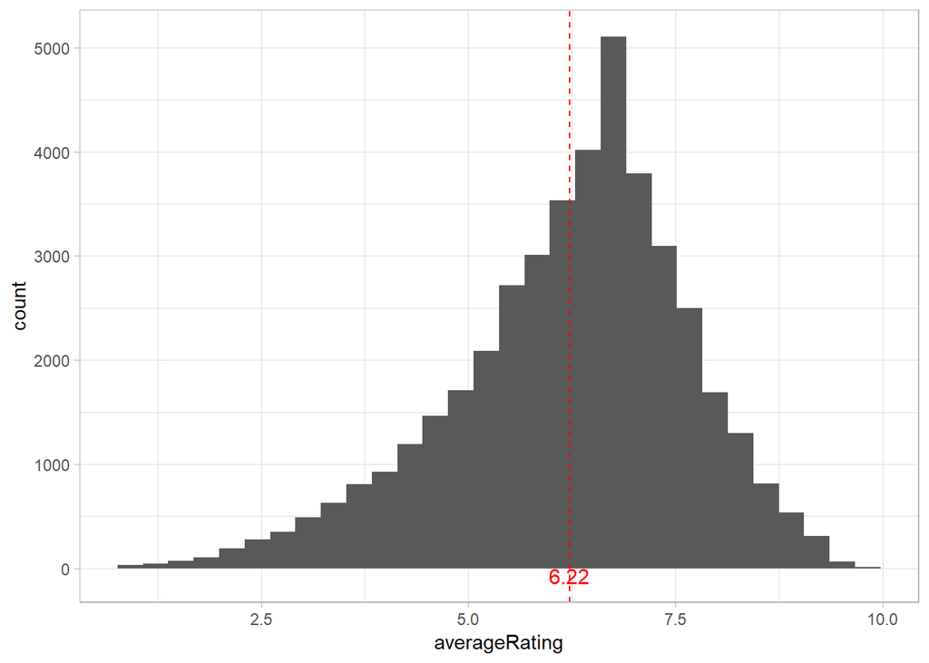

```r
mean <- mean(movie_df$averageRating, na.rm = T) %>% round(2)
movie_df %>%
  ggplot()+
    geom_histogram(aes(averageRating))+
    geom_vline(xintercept = mean, colour = "red", linetype="dashed", show.legend = T)+
    annotate("text", label = mean, x = mean, y= -70, size = 4, colour = "red")+
    theme_light()
```

# 2. Who is most likeky to be in a bad/good movie?

將averageRating小於第一四分位數者定義為爛電影，高於第三四分位數者定義為好電影。觀察爛電影與好電影中，哪些人出現的次數最多。

## 2.1 Bad movies

```r
bad_movie <- movie_df %>%
  filter(averageRating < 5.4)

bad_movie <- df %>%
  filter(tconst %in% bad_movie$tconst)
```

```r
bad_movie %>%
  count(nconst, main_category, primaryName) %>%
  filter(!is.na(primaryName)) %>%
  arrange(desc(n)) %>%
  slice(1:50)
```

| nconst | main_category | primaryName | n |
| --- | --- | --- | --- |
| nm0000616 | actor | Eric Roberts | 62 |
| nm0490375 | producer | David Michael Latt | 42 |
| nm0001744 | actor | Tom Sizemore | 33 |
| nm0001803 | actor | Danny Trejo | 29 |
| nm0000514 | actor | Michael Madsen | 26 |
| nm1930572 | composer | Kevin MacLeod | 26 |
| nm0103977 | actor | Brahmanandam | 24 |
| nm0827500 | producer | David S. Sterling | 24 |
| nm1413593 | producer | Stan Spry | 24 |
| nm0940598 | producer | Eric Scott Woods | 22 |

[output cut: 40 more lines]

上表以及下圖可以看到最常出現在爛電影的人、其分類，以及出現的次數。

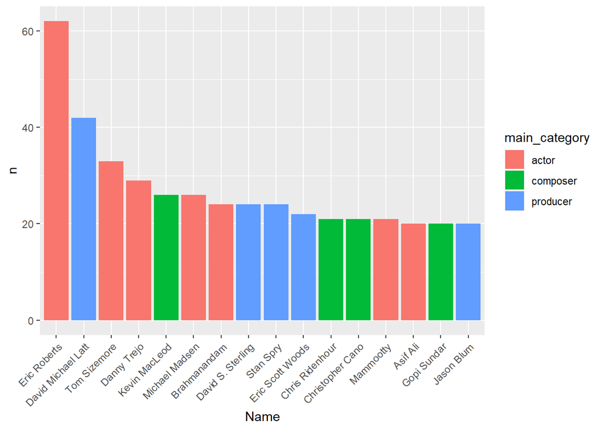

```r
bad_movie %>%
  count(nconst, main_category, primaryName) %>%
  filter(!is.na(primaryName)) %>%
  top_n(15) %>%
  ggplot()+
  geom_col(aes(x = reorder(primaryName, -n), y = n, fill = main_category))+
  theme(axis.text.x=element_text(angle=45, hjust=1))+
  xlab("Name")
```

## 2.2 Good movies

```r
good_movie <- movie_df %>%
  filter(averageRating > 7.2)

good_movie <- df %>%
  filter(tconst %in% good_movie$tconst)
```

```r
good_movie %>%
  count(nconst, main_category, primaryName) %>%
  filter(!is.na(primaryName)) %>%
  arrange(desc(n)) %>%
  slice(1:50)
```

| nconst | main_category | primaryName | n |
| --- | --- | --- | --- |
| nm0000636 | writer | William Shakespeare | 36 |
| nm1930572 | composer | Kevin MacLeod | 26 |
| nm2065631 | composer | Gopi Sundar | 15 |
| nm0159008 | self | Noam Chomsky | 14 |
| nm0329125 | composer | Joel Goodman | 14 |
| nm0215842 | producer | Vicente G. del Rosario III | 13 |
| nm1827744 | composer | Paul Brill | 13 |
| nm0000217 | self | Martin Scorsese | 12 |
| nm0598531 | writer | Mark Monroe | 12 |
| nm1907447 | writer | Titien Wattimena | 12 |

[output cut: 40 more lines]

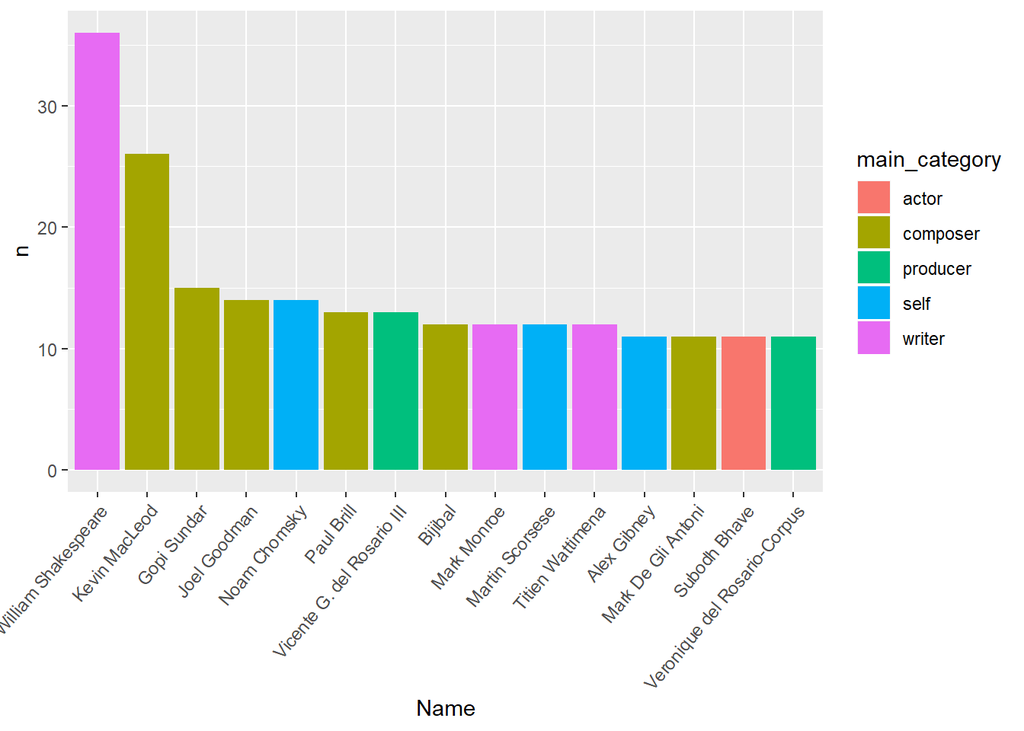

```r
good_movie %>%
  count(nconst, main_category, primaryName) %>%
  filter(!is.na(primaryName)) %>%
  top_n(15) %>%
  ggplot()+
  geom_col(aes(x = reorder(primaryName, -n), y = n, fill = main_category))+
  theme(axis.text.x=element_text(angle=50, hjust=1))+
  xlab("Name")
```

# 3. Mean rating of each crew

由於是否常出現在爛/好電影也可能受到這個人總出現次數的影響，因此我們也可以單看每個人在他所出現的電影中得到的平均分數。  
filtering people at least appear 3 times in different movie: 選取投票次數10次以上的電影，並選取至少出現在三個不同電影中的人，存取在crew這個dataframe。共28345個人。

```r
crew <- df %>%
  filter(titleType == "movie") %>%
  filter(numVotes >= 10) %>%
  count(nconst, tconst) %>%
  count(nconst) %>%
  filter(n >= 3)

nrow(crew)
```

```
## [1] 28345
```

計算在crew這個dataframe中，每個人的平均分數，定義crew_average_rating欄位，存在crew_average_rating這個dataframe。

```r
crew_average_rating <- df %>%
  filter(titleType == "movie") %>%
  filter(numVotes >= 10) %>%
  filter(nconst %in% crew$nconst) %>%
  group_by(nconst) %>%
  mutate(crew_average_rating = mean(averageRating))

crew_average_rating %>%
  select(tconst, nconst, primaryName, crew_average_rating) %>%
  head()
```

| tconst | nconst | primaryName | crew_average_rating |
| --- | --- | --- | --- |
| tt0063540 | nm0347899 | Gulzar | 6.350000 |
| tt0069049 | nm0000953 | Peter Bogdanovich | 6.260000 |
| tt0069049 | nm0000080 | Orson Welles | 6.740000 |
| tt0069049 | nm0550881 | Frank Marshall | 6.671429 |
| tt0069204 | nm2147526 | Asrani | 4.677778 |
| tt0069204 | nm0347899 | Gulzar | 6.350000 |

## 3.1 Top 10 crews

平均得分最高的10個人。

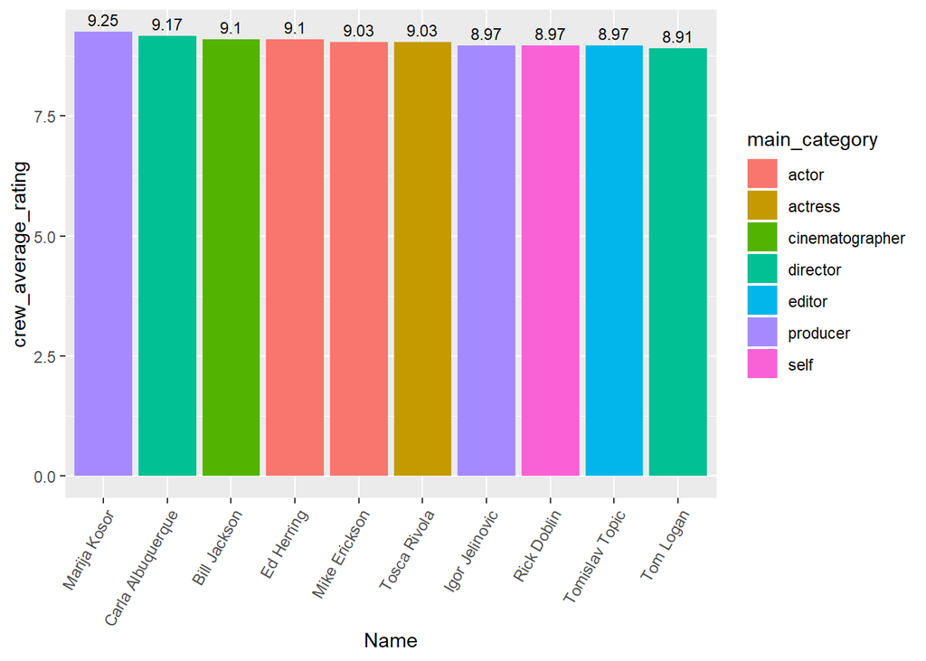

```r
crew_average_rating %>%
  slice(1) %>%
  filter(!is.na(primaryName)) %>%
  ungroup() %>%
  arrange(desc(crew_average_rating)) %>%
  top_n(10) %>%
  ggplot(aes(x = reorder(primaryName, -crew_average_rating), y = crew_average_rating, fill = main_category)) +
  geom_col() +
  theme(axis.text.x=element_text(angle=60, hjust=1))+
  geom_text(aes(label = crew_average_rating %>% round(2)), vjust = -0.5, size = 3)+
  xlab("Name")
```

## 3.2 Last 10 crews

平均得分最低的10個人。

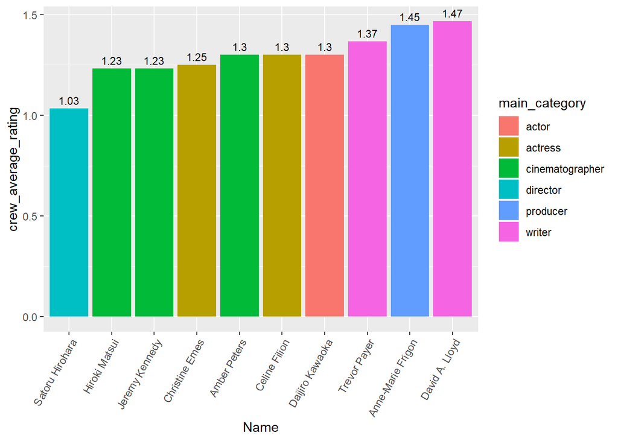

```r
crew_average_rating %>%
  slice(1) %>%
  filter(!is.na(primaryName)) %>%
  ungroup() %>%
  arrange(crew_average_rating) %>%
  top_n(-10) %>%
  ggplot(aes(x = reorder(primaryName, crew_average_rating), y = crew_average_rating, fill = main_category))+
  geom_col()+
  theme(axis.text.x=element_text(angle=60, hjust=1))+
  geom_text(aes(label = crew_average_rating %>% round(2)), vjust = -0.5, size = 3)+
  xlab("Name")
```

# 4. Who’s the highest/lowest rated double?

上面都是以個人為單位分析，接下來要看當兩個人同時出現時其平均得分。

## 4.1 Finding doubles appears >= 3 times

創建一network_df，將每一部電影中出現的所有兩人排列組合(nconst與next_nconst欄位)。 篩選出出現大於等於三次的雙人組合，並將他們的平均得分與出現次數存在double_rating這個dataframe。

```r
network_df <- df %>%
  filter(titleType == "movie") %>%
  filter(numVotes >= 10) %>%
  select(tconst, nconst, averageRating) %>%
  group_by(tconst) %>%
  arrange(desc(nconst)) %>%
  mutate(next_nconst = lag(nconst)) %>%
  filter(!is.na(next_nconst)) %>%
  ungroup() %>%
  select(-tconst) %>%
  mutate(id1 = as.numeric(substr(nconst, 3, length(nconst))),
         id2 = as.numeric(substr(next_nconst, 3, length(next_nconst)))) %>%
  mutate(new_nconst = ifelse(id1 > id2, next_nconst, nconst),
         new_next_nconst = ifelse(id1 > id2, nconst, next_nconst)) %>%
  mutate(nconst = new_nconst, next_nconst = new_next_nconst) %>%
  select(nconst, next_nconst, averageRating)

network_df_flt <- network_df %>%
  count(nconst, next_nconst) %>%
  filter(n>=3)

double_rating <- network_df %>%
  right_join(network_df_flt, by = c("nconst", "next_nconst")) %>%
  group_by(nconst, next_nconst) %>%
  mutate(double_average_rating = mean(averageRating)) %>%
  select(-averageRating) %>%
  slice(1)

head(double_rating)
```

| nconst | next_nconst | n | double_average_rating |
| --- | --- | --- | --- |
| nm0000118 | nm0384185 | 3 | 6.133333 |
| nm0000147 | nm0000173 | 3 | 6.633333 |
| nm0000158 | nm0000229 | 3 | 7.433333 |
| nm0000165 | nm0004976 | 4 | 6.400000 |
| nm0000234 | nm0228690 | 3 | 6.800000 |
| nm0000264 | nm0003900 | 3 | 7.000000 |

Merge tables: 將所有人的id與姓名存在crew_name，並用double_rating與crew_name、crew_main_cat left_join，得到nconst與next_nconst的姓名與分類。

```r
crew_name <- df %>%
  select(nconst, primaryName) %>%
  group_by(nconst, primaryName) %>%
  slice(1) %>%
  ungroup()

double_rating <- double_rating %>%
  left_join(crew_main_cat, by = "nconst") %>%
  rename(nconst_cat = main_category) %>%
  left_join(crew_main_cat, by = c("next_nconst" = "nconst")) %>%
  rename(next_nconst_cat = main_category)

double_rating <- double_rating %>%
  left_join(crew_name, by = "nconst") %>%
  rename(nconst_name = primaryName) %>%
  left_join(crew_name, by = c("next_nconst" = "nconst")) %>%
  rename(next_nconst_name = primaryName)

head(double_rating)
```

| nconst | next_nconst | n | double_average_rating | nconst_cat | next_nconst_cat | nconst_name | next_nconst_name |
| --- | --- | --- | --- | --- | --- | --- | --- |
| nm0000118 | nm0384185 | 3 | 6.133333 | self | writer | John Carpenter | Debra Hill |
| nm0000147 | nm0000173 | 3 | 6.633333 | self | self | Colin Firth | Nicole Kidman |
| nm0000158 | nm0000229 | 3 | 7.433333 | self | self | Tom Hanks | Steven Spielberg |
| nm0000165 | nm0004976 | 4 | 6.400000 | self | self | Ron Howard | Brian Grazer |
| nm0000234 | nm0228690 | 3 | 6.800000 | self | producer | Charlize Theron | A.J. Dix |
| nm0000264 | nm0003900 | 3 | 7.000000 | self | cinematographer | Pedro Almodovar | Jose Luis Alcaine |

## 4.2 Top 10

平均得分最佳十名的雙人組名單

```r
double_rating %>%
  ungroup() %>%
  arrange(desc(double_average_rating)) %>%
  slice(1:10)
```

| nconst | next_nconst | n | double_average_rating | nconst_cat | next_nconst_cat | nconst_name | next_nconst_name |
| --- | --- | --- | --- | --- | --- | --- | --- |
| nm6795049 | nm6795050 | 3 | 9.300000 | writer | writer | NA | NA |
| nm0517665 | nm4847578 | 4 | 9.100000 | director | cinematographer | Tom Logan | Bill Jackson |
| nm4847578 | nm4847702 | 4 | 9.100000 | cinematographer | actor | Bill Jackson | Ed Herring |
| nm1191763 | nm8802619 | 3 | 9.033333 | actor | actress | Mike Erickson | NA |
| nm1126245 | nm1126246 | 3 | 8.833333 | director | composer | Branko Istvancic | Pere Istvancic |
| nm2545643 | nm2611428 | 3 | 8.733333 | director | director | Elizabeth Holloway | Dawn Gifford Engle |
| nm6510423 | nm6510425 | 3 | 8.733333 | producer | producer | NA | NA |
| nm1948790 | nm3013682 | 3 | 8.600000 | writer | cinematographer | Aaron Cohen | Alex Agnant |
| nm5724719 | nm5756214 | 3 | 8.433333 | actor | actor | NA | NA |
| nm6083333 | nm6674416 | 3 | 8.366667 | actor | actor | NA | NA |

## 4.3 Last 10

平均得分最差前十名的雙人組名單

```r
double_rating %>%
  ungroup() %>%
  arrange(double_average_rating) %>%
  slice(1:10)
```

| nconst | next_nconst | n | double_average_rating | nconst_cat | next_nconst_cat | nconst_name | next_nconst_name |
| --- | --- | --- | --- | --- | --- | --- | --- |
| nm1448482 | nm1459644 | 4 | 1.275000 | director | composer | Brett Kelly | Christopher Nickel |
| nm6594610 | nm7009376 | 4 | 1.275000 | actor | actress | NA | NA |
| nm0676316 | nm1448482 | 3 | 1.300000 | cinematographer | director | Amber Peters | Brett Kelly |
| nm1578970 | nm2784796 | 4 | 1.350000 | producer | writer | Anne-Marie Frigon | Trevor Payer |
| nm1448482 | nm1578970 | 3 | 1.466667 | director | producer | Brett Kelly | Anne-Marie Frigon |
| nm0309575 | nm0379782 | 3 | 1.800000 | actor | actor | Jon-Paul Gates | Hans Hernke |
| nm0725808 | nm1700105 | 3 | 2.166667 | composer | composer | Chris Ridenhour | Christopher Cano |
| nm1953143 | nm3147111 | 3 | 2.233333 | director | director | Steven M. Smith | Zane Casablanca |
| nm0040630 | nm0490375 | 5 | 2.480000 | director | producer | Mark Atkins | David Michael Latt |
| nm2374888 | nm2386198 | 4 | 2.525000 | actor | actor | Tim Hatch | Jeff Kirkendall |

# 5. Cluster for crews

本部分嘗試將double_rating轉為一網絡的資料型態，再轉為鄰接矩陣(adjacency matrix)，進行hierachical clustering以及 Spectral clustring兩種分群法。  
## Make network using igraph package, and transform to adjacency matrix

```r
library(igraph)
g <- graph_from_data_frame(double_rating %>% select(nconst, next_nconst, n, double_average_rating),  directed = F)

A <- as_adjacency_matrix(g, attr = "n")
A[100:110, 100:110]
```

```
## 11 x 11 sparse Matrix of class "dgCMatrix"
##
## nm0098661 . . . . . . . . . . .
## nm0098953 . . . . . . . . . . .
## nm0099521 . . . . . . . . . . .
## nm0100559 . . . . . . . . . . .
## nm0101750 . . . . . . . . . . .
## nm0103976 . . . . . . 3 . . . .
## nm0103977 . . . . . 3 . . . . .
## nm0104787 . . . . . . . . . . .
## nm0106068 . . . . . . . . . . .
## nm0110292 . . . . . . . . . . .
## nm0110357 . . . . . . . . . . .
```

## 5.1 Hierachical clustering

### 5.1.1 Simlilarity matrix and dist

用Pearson Correlation計算Simlilarity matrix，並轉為r中的dist class

```r
S <- qlcMatrix::corSparse(A)
H <- 1-S
d <- as.dist(H)
print(S[1:5, 1:5])
```

```
##               [,1]          [,2]          [,3]          [,4]          [,5]
## [1,]  1.0000000000 -0.0003590664 -0.0003590664 -0.0003590664 -0.0003590664
## [2,] -0.0003590664  1.0000000000 -0.0003590664 -0.0003590664 -0.0003590664
## [3,] -0.0003590664 -0.0003590664  1.0000000000 -0.0003590664 -0.0003590664
## [4,] -0.0003590664 -0.0003590664 -0.0003590664  1.0000000000 -0.0003590664
## [5,] -0.0003590664 -0.0003590664 -0.0003590664 -0.0003590664  1.0000000000
```

```r
print(d[1:5])
```

```
## [1] 1.000359 1.000359 1.000359 1.000359 1.000359
```

由average silhouette得到最佳分群數為k=3

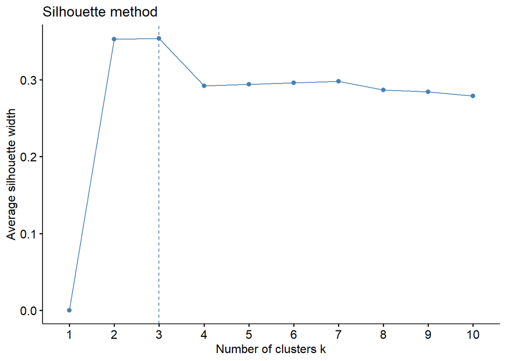

```r
library(factoextra)
silhouette_for_hc <- fviz_nbclust(S,
             FUNcluster = factoextra::hcut,
             method = "silhouette",
             k.max = 10
             ) +  labs(title="Silhouette method")
```

### 5.1.2 Make clusters

```r
hc_cluster_tree <- hclust(d, method = "average")
hc_cluster <- cutree(hc_cluster_tree, k=3)
V(g)$hc_cluster <- hc_cluster

df_cluster <- igraph::as_data_frame(g, what = "vertices") %>%
  left_join(crew_average_rating %>% slice(1) %>% select(nconst, crew_average_rating),
            by = c("name" = "nconst"))
df_cluster %>%
  group_by(hc_cluster) %>%
  summarise(n = n(),
            mean_rating = mean(crew_average_rating))
```

| hc_cluster | n | mean_rating |
| --- | --- | --- |
| 1 | 2784 | 6.062745 |
| 2 | 1 | 5.684615 |
| 3 | 1 | 4.933333 |

## 5.2 Spectral clustring

### 5.2.1 Define matrics & determine k

定義make_affinity函數，可將similarity matrix轉為affinity matrix。

```r
# reference: http://www.di.fc.ul.pt/~jpn/r/spectralclustering/spectralclustering.html
make_affinity <- function(S, n.neighboors=2) {
  N <- length(S[,1])

  if (n.neighboors >= N) {  # fully connected
    A <- S
  } else {
    A <- matrix(rep(0,N^2), ncol=N)
    for(i in 1:N) { # for each line
      # only connect to those points with larger similarity
      best.similarities <- sort(S[i,], decreasing=TRUE)[1:n.neighboors]
      for (s in best.similarities) {
        j <- which(S[i,] == s)
        A[i,j] <- S[i,j]
        A[j,i] <- S[i,j] # to make an undirected graph, ie, the matrix becomes symmetric
      }
    }
  }
  A
}
```

```r
Aff <- make_affinity(S, 3)
D <- diag(apply(Aff, 1, sum))
U <- D - Aff
```

利用U矩陣的特徵值排序，可以得到最佳的分群數為3。

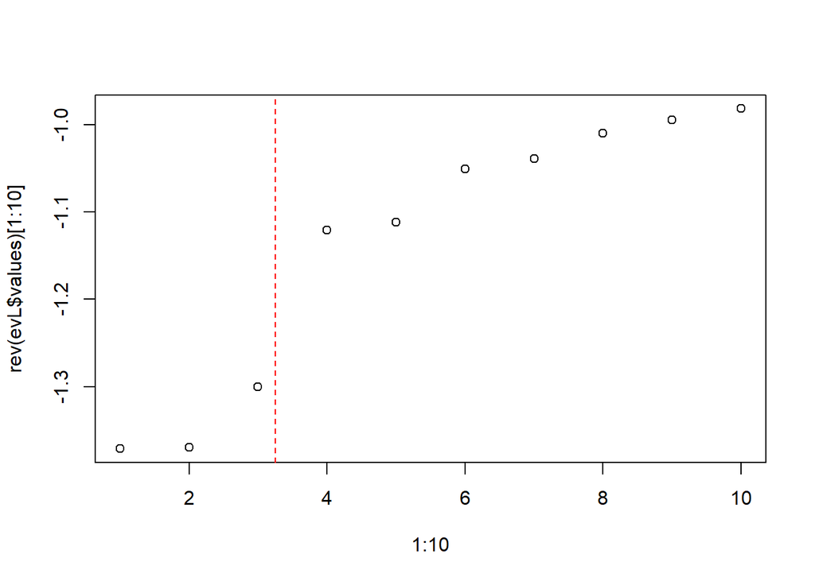

```r
k <- 2 #降到2維空間
evL <- eigen(U, symmetric = T)
Z <- evL$vectors[ ,(ncol(evL$vectors)-k+1):ncol(evL$vectors)]

plot(1:10, rev(evL$values)[1:10])
abline(v=3.25, col="red", lty=2)
```

Spectral clustering的分群結果也呈現兩個點自己一群，其他全部點為一群。可能因為這個矩陣過於稀疏，不適用於這些分群的算法。

```r
sp_cluster <- kmeans(Z, centers=3, nstart=5)
V(g)$cluster <- sp_cluster$cluster

df_cluster <- igraph::as_data_frame(g, what = "vertices") %>%
  left_join(crew_average_rating %>% slice(1) %>% select(nconst, crew_average_rating),
            by = c("name" = "nconst"))
df_cluster %>%
  group_by(cluster) %>%
  summarise(n = n(),
            mean_rating = mean(crew_average_rating))
```

| cluster | n | mean_rating |
| --- | --- | --- |
| 1 | 2784 | 6.062202 |
| 2 | 1 | 6.425000 |
| 3 | 1 | 5.704762 |

# 6. Community analysis

上述分群的演算法都無法讓我們了解crews彼此聚集的狀況，但我們可以利用網絡中的communities，也就是網絡中的小群體來了解這些電影工作者彼此的連結。 ##Using leading eigenvalue of modularity matrix to form communities 使用igraph套件中的cluster_leading_eigen函式，利用leading eigenvalue method建立communities。  
由結果可見此網絡可分為1103個communities。

```r
community <- cluster_leading_eigen(g, weights=E(g)$n)
community
```

```
## IGRAPH clustering leading eigenvector, groups: 1103, mod: 1
## + groups:
##   $`1`
##   [1] "nm0000118" "nm0384185"
##
##   $`2`
##   [1] "nm0000147" "nm0000173"
##
##   $`3`
##   [1] "nm0000158" "nm0000229"
##
##   $`4`
##   + ... omitted several groups/vertices
```

## 6.1 Defining nodes attributes

將每個人(node)是哪一個community的成員加在該node的屬性上。另外也加上平均得分與姓名。

```r
V(g)$community <- community$membership
nodes_df <- igraph::as_data_frame(g, what = "vertices") %>%
  left_join(crew_average_rating %>%
              slice(1) %>%
              select(nconst, crew_average_rating, primaryName), by = c("name" = "nconst")) %>%
  left_join(crew_main_cat, by = c("name" = "nconst"))
```

## 6.2 Find best/worst communitis with 5 or more members

在這個網絡中共有2786個人，community則有1103個，因此可以懷疑很多community都只有一個人。因此將有5人以上的community篩選出來進行分析。

```r
community_over_5 <- nodes_df %>%
  count(community) %>%
  arrange(desc(n)) %>%
  filter(n >= 5)

community_over_5
```

| community | n |
| --- | --- |
| 32 | 26 |
| 55 | 23 |
| 53 | 21 |
| 505 | 17 |
| 58 | 15 |
| 810 | 15 |
| 621 | 13 |
| 135 | 12 |
| 427 | 10 |
| 62 | 9 |

[output cut: 43 more lines]

將每個community成員的rating平均，得到該community平均的rating，進行排名。

```r
community_rating <- nodes_df %>%
  filter(community %in% community_over_5$community) %>%
  group_by(community) %>%
  mutate(community_average_rating = mean(crew_average_rating)) %>%
  slice(1) %>%
  select(community, community_average_rating)

community_rating %>% arrange(desc(community_average_rating))
```

| community | community_average_rating |
| --- | --- |
| 672 | 7.990476 |
| 53 | 7.034889 |
| 1047 | 7.025040 |
| 270 | 7.009081 |
| 58 | 6.984721 |
| 758 | 6.948114 |
| 471 | 6.889286 |
| 329 | 6.750283 |
| 523 | 6.718667 |
| 536 | 6.650000 |

[output cut: 43 more lines]

## 6.3 Who is in the best/worst community?

找出是誰在最好以及最壞的community。  
Best communities

```r
nodes_df %>% filter(community == 672)
```

| name | hc_cluster | cluster | community | crew_average_rating | primaryName | main_category |
| --- | --- | --- | --- | --- | --- | --- |
| nm1860184 | 1 | 1 | 672 | 7.520000 | Cristiano Ronaldo | self |
| nm2048873 | 1 | 1 | 672 | 7.580000 | Sergio Ramos | self |
| nm2323995 | 1 | 1 | 672 | 8.166667 | Luka Modric | self |
| nm3294525 | 1 | 1 | 672 | 8.166667 | Karim Benzema | self |
| nm3819618 | 1 | 1 | 672 | 8.166667 | Toni Kroos | self |
| nm5323811 | 1 | 1 | 672 | 8.166667 | NA | self |
| nm5347007 | 1 | 1 | 672 | 8.166667 | Gareth Bale | self |

Worst Communities

```r
nodes_df %>% filter(community == 333)
```

| name | hc_cluster | cluster | community | crew_average_rating | primaryName | main_category |
| --- | --- | --- | --- | --- | --- | --- |
| nm0676316 | 1 | 1 | 333 | 1.300000 | Amber Peters | cinematographer |
| nm1448482 | 1 | 1 | 333 | 1.661538 | Brett Kelly | director |
| nm1578970 | 1 | 1 | 333 | 1.450000 | Anne-Marie Frigon | producer |
| nm1459644 | 1 | 1 | 333 | 2.912500 | Christopher Nickel | composer |
| nm2784796 | 1 | 1 | 333 | 1.366667 | Trevor Payer | writer |

## 6.4 Visualization of communities over 5 members

利用visNetwork套件將網絡中，超過5人的community視覺化。(若沒有出現要等他跑一下) 該網絡圖為可互動式，可以進行縮放、點擊、拖曳等動作。  
可以看到該網絡分成一個個小群體，利用左上角的選單選取community，會發現每個小群體與community的分類是一致的。  
另外視覺化中，透過顏色來區分category，透過點擊node也可以看到實際連結的情況，放大則可以清楚看到每個點的姓名。

```r
library(visNetwork)
g <- graph_from_data_frame(double_rating %>% select(nconst, next_nconst, n, double_average_rating), directed = F, vertices = nodes_df)

sub_g <- induced_subgraph(g, which(V(g)$community %in% community_over_5$community))

sub_g_vis <- toVisNetworkData(sub_g)
sub_g_vis$nodes <- sub_g_vis$nodes %>%
  rename(group = main_category, id = label, label = primaryName)

visNetwork(nodes = sub_g_vis$nodes, edges = sub_g_vis$edges) %>%
    visInteraction(navigationButtons = TRUE) %>%
    visOptions(highlightNearest = TRUE, selectedBy  = "community") %>%
    visLegend(width = 0.2, position = "right", main = "Category")
```

[interactive chart not shown]

# 7. Make Predictive Model through Scikit-Learn

本部分將電影依rating中數區二分為好/壞，並以每個劇組成員是否出現的sparse matrix進行預策性建模。  
由於sklearn.feature_extraction.text中的CountVectorizer可以幫我們建立sparse matrix，因此先在r中建立movie_good_or_bad的dataframe，共三個欄位:電影id、劇組成員(以空白分隔)，是否是好電影(1/0)。之後再用python讀取該檔案進行建模。

總共有42855部電影，234337個劇組人員。

```r
const <- df %>%
  select(tconst, nconst) %>%
  filter(tconst %in% movie_df$tconst) %>%
  left_join(movie_df %>% select(tconst, averageRating),
            by = "tconst") %>%
  mutate(good_or_bad = ifelse(averageRating > median(movie_df$averageRating), 1, 0))
const %>% count(nconst) %>% nrow()
```

```
## [1] 234337
```

一部電影最多有10個crew

```r
df$ordering %>% max()
```

```
## [1] 10
```

建立movie_good_or_bad dataframe

```r
movie_good_or_bad <- const %>%
  arrange(tconst) %>%
  group_by(tconst) %>%
  mutate(nconst_1 = lag(nconst, 1)) %>%
  mutate(nconst_2 = lag(nconst, 2)) %>%
  mutate(nconst_3= lag(nconst, 3)) %>%
  mutate(nconst_4= lag(nconst, 4)) %>%
  mutate(nconst_5= lag(nconst, 5)) %>%
  mutate(nconst_6= lag(nconst, 6)) %>%
  mutate(nconst_7= lag(nconst, 7)) %>%
  mutate(nconst_8= lag(nconst, 8)) %>%
  mutate(nconst_9= lag(nconst, 9)) %>%
  mutate(nconst_1 = ifelse(is.na(nconst_1), "", nconst_1),
         nconst_2 = ifelse(is.na(nconst_2), "", nconst_2),
         nconst_3 = ifelse(is.na(nconst_3), "", nconst_3),
         nconst_4 = ifelse(is.na(nconst_4), "", nconst_4),
         nconst_5 = ifelse(is.na(nconst_5), "", nconst_5),
         nconst_6 = ifelse(is.na(nconst_6), "", nconst_6),
         nconst_7 = ifelse(is.na(nconst_7), "", nconst_7),
         nconst_8 = ifelse(is.na(nconst_8), "", nconst_8),
         nconst_9 = ifelse(is.na(nconst_9), "", nconst_9)) %>%
  unite(col = "crews",  c(nconst, nconst_1:nconst_9), sep = " ") %>%
  slice(n())
movie_good_or_bad <- movie_good_or_bad %>% select(-averageRating)

#write.csv(movie_good_or_bad, "movie_good_or_bad.csv", row.names = F)
```

```r
head(movie_good_or_bad)
```

|  | tconst | crews | good_or_bad |
| --- | --- | --- | --- |
| 1 | tt0063540 | nm1391276 nm0347899 nm1194313 nm0023551 nm0712540 nm0474876 nm0756379 nm0904537 nm0474801 nm0006210 | 1 |
| 2 | tt0066787 | nm0536728 nm2600399 nm0002411 nm0794511 nm0754829 nm0451809 nm0045119 | 1 |
| 3 | tt0069049 | nm0004372 nm0006166 nm1475059 nm0550881 nm0000080 nm0001782 nm0000953 nm0462648 nm0001379 nm0613657 | 1 |
| 4 | tt0069204 | nm1877741 nm0244884 nm0006005 nm0347899 nm0611531 nm1875977 nm1027929 nm2147526 nm0037026 nm0315917 | 0 |
| 5 | tt0100275 | nm1856792 nm0462571 nm1360635 nm0765384 nm0749914 nm1415193 nm0721280 nm0728971 nm0016013 nm0005948 | 1 |
| 6 | tt0112502 | nm0373872 nm0227234 nm6883878 | 0 |

共42855部電影

```r
nrow(movie_good_or_bad)
```

```
## [1] 42855
```

## 7.1 Read data in python

使用reticulate套件運行python kernel

```r
library(reticulate)
use_python("C:/Users/User/Anaconda3/python")
```

=============================Belows are python codes=============================

```python
import pandas as pd
movie = pd.read_csv("movie_good_or_bad.csv")
movie.head()
```

```
##       tconst                                              crews  good_or_bad
## 0  tt0063540  nm1391276 nm0347899 nm1194313 nm0023551 nm0712...            1
## 1  tt0066787  nm0536728 nm2600399 nm0002411 nm0794511 nm0754...            1
## 2  tt0069049  nm0004372 nm0006166 nm1475059 nm0550881 nm0000...            1
## 3  tt0069204  nm1877741 nm0244884 nm0006005 nm0347899 nm0611...            0
## 4  tt0100275  nm1856792 nm0462571 nm1360635 nm0765384 nm0749...            1
```

## 7.2 Make prdictive model

Import needed modules

```python
from sklearn.feature_extraction.text import CountVectorizer
from sklearn.linear_model import SGDClassifier
from sklearn.model_selection import  StratifiedKFold, GridSearchCV
from sklearn.pipeline import Pipeline
from sklearn.feature_selection import SelectPercentile, chi2
from sklearn.metrics import f1_score, accuracy_score
import numpy as np
```

使用SGDClassifier為模型，chi square值為feature selection基準，並調整選取變項數（在本模型中等於所有劇組人數）的百分比。  
模型會經過k=4的cross-validation，以這4次平均的accuracy score、f1 score為判斷模型好壞的基準。

```python
skf =  StratifiedKFold(n_splits = 4, shuffle = True, random_state=47)
all_accuracy_list = []
all_f1_list = []
for train_index, test_index in skf.split(movie.crews, movie.good_or_bad):
    X_train, X_test = movie.crews[train_index], movie.crews[test_index]
    y_train, y_test = movie.good_or_bad[train_index], movie.good_or_bad[test_index]

    accuracy_list = []
    f1_list = []

    for p in range(10, 101, 10):
        pipeline = Pipeline([
            ('vect', CountVectorizer()),
            ('chi_2', SelectPercentile(chi2, percentile=p)),
            ('clf', SGDClassifier())
            ])
        pipeline.fit(X_train, y_train)
        y_pred = pipeline.predict(X_test)

        accuracy = accuracy_score(y_test, y_pred)
        f1 = f1_score(y_test, y_pred)

        accuracy_list.append(accuracy)
        f1_list.append(f1)
    all_accuracy_list.append(accuracy_list)
    all_f1_list.append(f1_list)
```

```python
acc_array = np.array(all_accuracy_list)
mean_acc = np.mean(acc_array, axis = 0)

f1_array = np.array(all_f1_list)
mean_f1 = np.mean(f1_array, axis = 0)
```

## 7.3 Visualization of model tuning

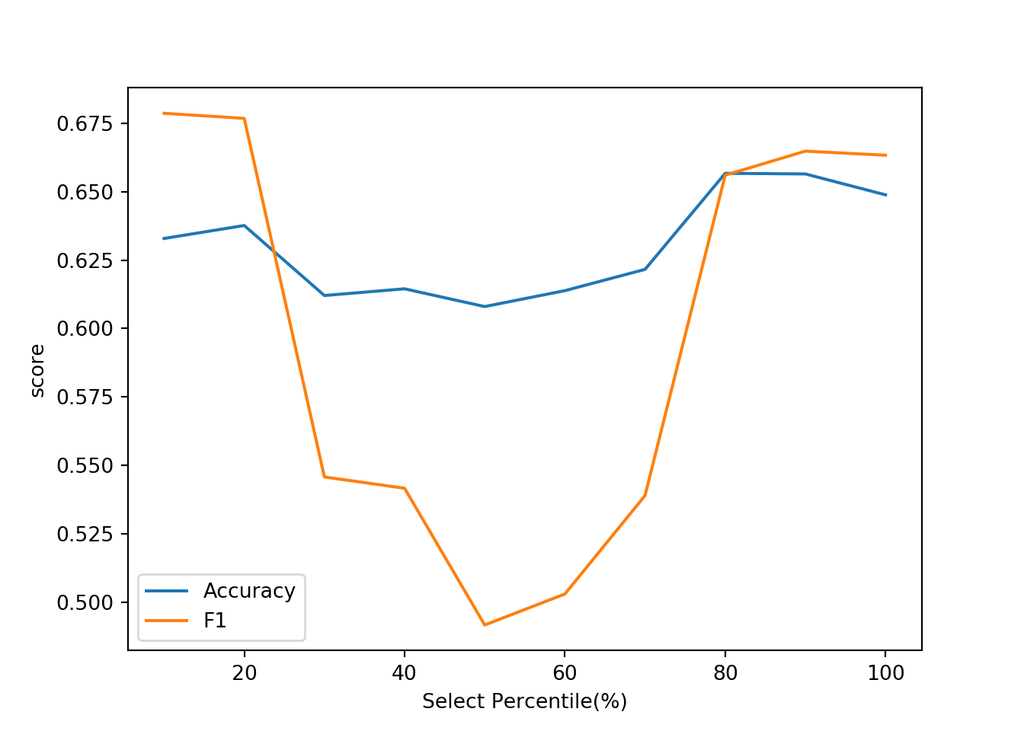

```python
import matplotlib.pyplot as plt

plt_df = pd.DataFrame({'x': list(range(10, 101, 10)), 'Accuracy': mean_acc, 'F1' : mean_f1})

plt.plot('x', 'Accuracy', data = plt_df)
plt.plot('x', 'F1', data = plt_df)
plt.xlabel('Select Percentile(%)')
plt.ylabel('score')
plt.legend()
plt.show()
```

## 7.4 Hyperparameter Tuning

使用GridSearchCV，校調chi square篩選變項的百分比、SGDClassifier中的loss function以及regularization term。  
結果顯示，chi square feature selecotr保留10%變項, 以hinge為SGDClassifier的loss function（等同SVC），正規化參數0.0001可以得到最佳的模型。

```python
param_grid = [{'chi_2__percentile': [10, 20, 80, 90, 100],
               'clf__loss':['log', 'hinge'],
               'clf__alpha': np.logspace(-4, 0, 3)}]

pipeline = Pipeline([
        ('vect', CountVectorizer()),
        ('chi_2', SelectPercentile(chi2)),
        ('clf', SGDClassifier())
        ])

gscv = GridSearchCV(pipeline, cv=5, param_grid=param_grid, scoring="f1")
gscv.fit(movie.crews, movie.good_or_bad)
```

```python
print(gscv.best_params_)
```

```
## {'chi_2__percentile': 10, 'clf__alpha': 0.0001, 'clf__loss': 'hinge'}
```

```python
print(gscv.best_score_)
```

```
## 0.6780424160840899
```

## 7.5 Crew with best chi square

上述使用chi square為feature selction的方法，也可以幫助我們了解那些變項（在本模型中即是哪些crew）在好/壞電影上較有區辨力。選取chi square最高的10個crew，再回去看他們的平均得分。

```python
vectorizer = CountVectorizer()
vect = vectorizer.fit_transform(movie.crews)

chi_score = chi2(vect, movie.good_or_bad)
best_chi_id = chi_score[0].argsort()[-10:]

best_chi_crew = [vectorizer.get_feature_names()[i] for i in best_chi_id]
best_chi_crew
```

[output not shown]

Chi square最高的10個crew的資料。

```r
best_chi_crew <- c('nm0725808', 'nm0000514', 'nm0827500', 'nm0000217', 'nm0000636', 'nm0940598', 'nm0159008', 'nm1413593', 'nm0000616', 'nm0490375')

crew_average_rating %>%
  slice(1) %>%
  select(nconst, primaryName, main_category, crew_average_rating) %>%
  filter(nconst %in% best_chi_crew)
```

| nconst | primaryName | main_category | crew_average_rating |
| --- | --- | --- | --- |
| nm0000217 | Martin Scorsese | self | 7.647059 |
| nm0000514 | Michael Madsen | actor | 4.971111 |
| nm0000616 | Eric Roberts | actor | 4.745556 |
| nm0000636 | William Shakespeare | writer | 7.209677 |
| nm0159008 | Noam Chomsky | self | 7.521739 |
| nm0490375 | David Michael Latt | producer | 3.061905 |
| nm0725808 | Chris Ridenhour | composer | 3.142857 |
| nm0827500 | David S. Sterling | producer | 3.055556 |
| nm0940598 | Eric Scott Woods | producer | 4.761290 |
| nm1413593 | Stan Spry | producer | 4.709677 |